# Exercício 1 - Machine Learning - Regressão Linear

Amanda Provetti

```r
library("tidyverse")
library("ggplot2")
```

Considere o conjunto de dados data.txt, que organiza em um arquivo de texto dados sobre os lucros de diversas empresas e a população da cidade na qual a respectiva empresa se localiza. Nosso objetivo, é conduzir uma análise de regressão linear simples para que possamos construir um modelo que busque explicar os dados que temos acesso. A variável explanatória, i.e., feature ou variável de entrada, é o conjunto de dados populacionais das cidades (baseados em 10,000 habitantes) em uma região analisada nos USA, enquanto a variável dependente, ou de saída, consiste nos lucros declarados pelas empresas (baseados em uma escala de $10,000 dólares) que atuam nas cidades da região analisada. De forma analítica, a função hipótese candidata no caso do modelo de regressão linear é dada por: hˆθ (x) = θ0 +θ1x1 Considere a função custo retratada pelo erro quadrático médio para construção do modelo de ML. Abaixo, seguem os itens que devemos solucionar neste desenvolvimento, visando alcançar o objetivo do exercício:

1. Faça a análise exploratória das variáveis de entrada e saída. Utilize os nomes population e profit

```r
data <- read.table('data.txt', sep = ',', col.names = c("Population", "Profit"))
```

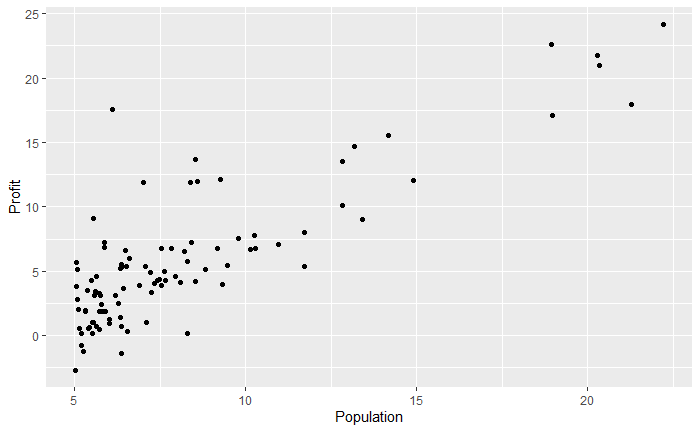

```r
data %>% ggplot(aes(x = Population, y = Profit)) +
  geom_point()
```

```r
summary(data)
```

```
   Population         Profit
 Min.   : 5.027   Min.   :-2.681
 1st Qu.: 5.708   1st Qu.: 1.987
 Median : 6.589   Median : 4.562
 Mean   : 8.160   Mean   : 5.839
 3rd Qu.: 8.578   3rd Qu.: 7.047
 Max.   :22.203   Max.   :24.147
```

2. Construa e treine o modelo preditivo de ML baseado em regressão linear simples.

```r
modelo_ML <- lm(Profit ~ Population, data = data)
modelo_ML
```

```
Call:
lm(formula = Profit ~ Population, data = data)

Coefficients:
(Intercept)   Population
     -3.896        1.193
```

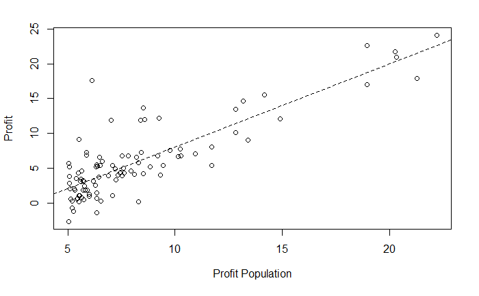

```r
data %>% plot(Profit ~ Population)
abline(modelo_ML,lty=2)
```

```r
cor(data) # 0.83 correlação forte
```

```
           Population    Profit
Population  1.0000000 0.8378732
Profit      0.8378732 1.0000000
```

3. Realize as predições do modelo sobre os dados de treinamento e calcule a média de seus resíduos

```r
mean(modelo_ML$residuals)
```

```
[1] -2.628508e-16
```

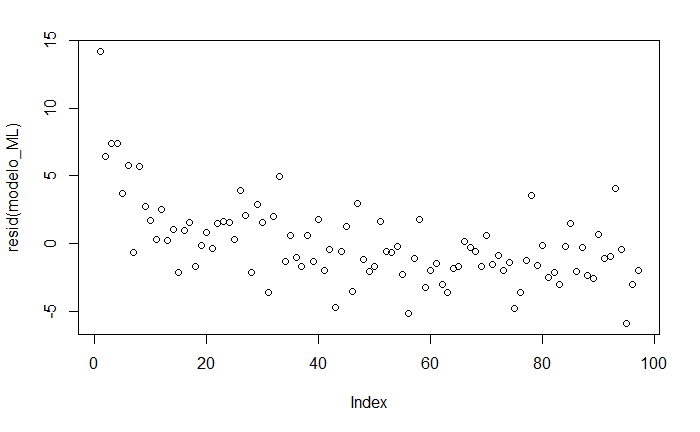

```r
plot( resid( modelo_ML ) )
```

```r
predict(modelo_ML)
```

```
        1         2         3         4         5         6         7         8         9        10
 3.393774  2.698951  6.267196  4.459272  3.095158  6.105301  5.023816  6.338181  3.842474  2.134527
       11        12        13        14        15        16        17        18        19        20
 2.917276 13.002348  2.945074  6.135723  2.833764  2.522024  3.698355  2.224601  3.774948  4.539921
       21        22        23        24        25        26        27        28        29        30
 3.488024 20.287011  2.654093  3.651469  2.743332 18.706242 11.408455  9.176289 11.823630 22.593145
       31        32        33        34        35        36        37        38        39        40
 2.370509  3.965595  7.137633  3.133335  5.900338  5.569032  5.762900  2.792724 11.417999  3.684039
       41        42        43        44        45        46        47        48        49        50
 2.554833  4.315273 10.072257  2.992437  5.439349  4.566526  2.153138  3.025485 10.062713  2.715534
       51        52        53        54        55        56        57        58        59        60
 5.099931  2.436484  4.961182  5.174973  3.659463  3.690601  3.589551  2.832571  7.211601  7.382682
       61        62        63        64        65        66        67        68        69        70
 6.633218  2.283298 21.490782 13.889965 18.722944  4.715775  6.000553  8.316112  2.665188 20.371716
       71        72        73        74        75        76        77        78        79        80
 8.196808  4.854524  3.269818  4.724961  2.101480  3.916084  5.098023  2.112933  8.361447  2.197877
       81        82        83        84        85        86        87        88        89        90
 2.939347  2.294155  3.686783  7.758607  3.877907  6.265525  7.056507  3.264807  2.690242  2.140254
       91        92        93        94        95        96        97
 2.913697  5.214940  3.108162  2.433740  5.998524 12.083712  2.590624
```

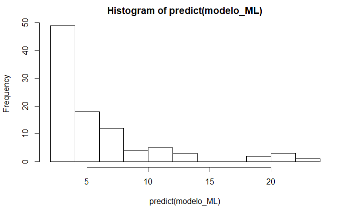

```r
hist(predict(modelo_ML))
```

4. Qual seria a predição de lucro de uma empresa, considerando uma cidade na região analisadas que conta com 100,000 habitantes?

```r
novos_dados <- data.frame("Population" = c(10, 12, 14, 16, 18, 20), stringsAsFactors = FALSE)
predicao_teste <- predict(modelo_ML, novos_dados)
predicao_teste <- data.frame("Precição (dólares)" = c(predicao_teste*10000))
predicao_teste
```

|  | Precição..dólares. |
| --- | --- |
| 1 | 80345.56 |
| 2 | 104206.23 |
| 3 | 128066.90 |
| 4 | 151927.57 |
| 5 | 175788.25 |
| 6 | 199648.92 |

– 5) Implemente o algoritmo do gradiente descendente.

```r
theta0 = 0
theta1 = 0
theta  = c(theta0,theta1)
num_iters     = 15000;
learning_rate = 0.01;

x = data$Population
y = data$Profit

Algoritmo_GD <- function(X, y, theta, learning_rate, num_iters){

  m = length(y)

  alpha = learning_rate

  for (i in 1:num_iters){
    h      = theta[1] + theta[2]*x
    Theta0 = theta[1]
    Theta1 = theta[2]
    Theta0 = Theta0 - alpha*(1/m)*sum((h - y))
    Theta1 = Theta1 - alpha*(1/m)*sum((h - y)*x)
    theta  = c(Theta0, Theta1)
  }
  theta
}
theta_GD <- Algoritmo_GD(x, y, theta, learning_rate, num_iters)
theta_GD
```

```
[1] -3.895781  1.193034
```

6. Solucione o problema de regressão linear com as equações normais e faça um comparativo

```r
x = data$Population
y = data$Profit
size_data = dim(data)
ones_data = replicate(size_data[1],1)

# Matriz de Design
X = data.frame(ones_data,x)
X = as.matrix(X)
#View(X)

theta_solution_norm_equations = solve(t(X) %*% X) %*% (t(X) %*% y)
theta_0_norm_eq = theta_solution_norm_equations[1]
theta_1_norm_eq = theta_solution_norm_equations[2]
theta_0_norm_eq
```

```
[1] -3.895781
```

```r
theta_1_norm_eq
```

```
[1] 1.193034
```

7. Compare os resultados do modelo construído com os parâmetros obtidos com o algoritmo GD

```r
summary(modelo_ML)
```

```
Call:
lm(formula = Profit ~ Population, data = data)

Residuals:
    Min      1Q  Median      3Q     Max
-5.8540 -1.9686 -0.5407  1.5360 14.1982

Coefficients:
            Estimate Std. Error t value Pr(>|t|)
(Intercept) -3.89578    0.71948  -5.415 4.61e-07 ***
Population   1.19303    0.07974  14.961  < 2e-16 ***
---
Signif. codes:  0 ‘***’ 0.001 ‘**’ 0.01 ‘*’ 0.05 ‘.’ 0.1 ‘ ’ 1

Residual standard error: 3.024 on 95 degrees of freedom
Multiple R-squared:  0.702, Adjusted R-squared:  0.6989
F-statistic: 223.8 on 1 and 95 DF,  p-value: < 2.2e-16
```

```r
summary(theta_GD)
```

```
    Min.  1st Qu.   Median     Mean  3rd Qu.     Max.
-3.89578 -2.62358 -1.35137 -1.35137 -0.07917  1.19303
```